# REFERENCE: Building a publication-style regression table from scratch

Raw numbers, odds ratios and a forest plot in one `gt` table

GRAPH Courses team

2026-07-30

# What this script is for

This is **not** an exercise. It is a worked reference you can copy from when you need to build a results table like the ones you see in journals: raw numerators and denominators, an observed-percentage bar, the odds ratio with its confidence interval, and a small forest plot, all in one table.

The point of building it from scratch is that you can then adapt every piece. In particular, this example shows how to handle a **continuous** predictor, which most template code gets wrong: the odds ratio comes from the continuous model, but the raw-number rows still have to be shown in bands, because “number of patients at age 23.4” is not a thing.

We use the `birthwt` data from the `MASS` package: 189 births at Baystate Medical Center, Springfield, Massachusetts, in 1986. The outcome is **low birth weight** (under 2500 g).

```r
if (!require(pacman)) install.packages("pacman")
pacman::p_load(tidyverse, broom, gt, glue, scales, MASS)
```

Note that `MASS` also has a `select()` function, which masks the `dplyr` one. Below we write `dplyr::select()` where we need it.

# PART 1: Prepare the data

```r
data(birthwt, package = "MASS")

births <- birthwt %>%
  transmute(
    low_bw = factor(low, levels = c(0, 1), labels = c("Normal", "Low")),
    age_years = age,
    weight_lb = lwt,
    race = factor(race, levels = 1:3, labels = c("White", "Black", "Other")),
    smoking = factor(smoke, levels = c(0, 1), labels = c("No", "Yes")),
    prior_ptl = factor(pmin(ptl, 2), levels = 0:2, labels = c("0", "1", "2+"))
  )

glimpse(births)
```

```
## Rows: 189
## Columns: 6
## $ low_bw    <fct> Normal, Normal, Normal, Normal, Normal, Normal, Normal, Norm…
## $ age_years <int> 19, 33, 20, 21, 18, 21, 22, 17, 29, 26, 19, 19, 22, 30, 18, …
## $ weight_lb <int> 182, 155, 105, 108, 107, 124, 118, 103, 123, 113, 95, 150, 9…
## $ race      <fct> Black, Other, White, White, White, Other, White, Other, Whit…
## $ smoking   <fct> No, No, Yes, Yes, Yes, No, No, No, Yes, Yes, No, No, No, No,…
## $ prior_ptl <fct> 0, 0, 0, 0, 0, 0, 0, 0, 0, 0, 0, 0, 0, 1, 0, 0, 0, 0, 0, 0, …
```

`ptl` is the count of previous premature labours. We collapse everything above 1 into a `2+` category, because the higher counts are rare.

Our five predictors cover the three shapes you will meet in practice:

- **Continuous:** `age_years`, `weight_lb`
- **Binary:** `smoking`
- **Polytomous:** `race`, `prior_ptl`

```r
births %>% count(low_bw)
```

```
##   low_bw   n
## 1 Normal 130
## 2    Low  59
```

# PART 2: Fit the models

## Continuous predictors, rescaled

A one-year change in age or a one-pound change in weight is a very small step, so the odds ratio comes out near 1 and is hard to read. Journals usually report a more meaningful unit: per 5 years, per 10 pounds.

The easiest way to do this is to divide the predictor by the step size before fitting. The coefficient then refers to that step.

```r
births <- births %>%
  mutate(age_per_5y = age_years / 5, weight_per_10lb = weight_lb / 10)
```

## Fit one univariable model per predictor

```r
model_age <- glm(low_bw ~ age_per_5y, family = binomial, data = births)
model_weight <- glm(low_bw ~ weight_per_10lb, family = binomial, data = births)
model_race <- glm(low_bw ~ race, family = binomial, data = births)
model_smoking <- glm(low_bw ~ smoking, family = binomial, data = births)
model_ptl <- glm(low_bw ~ prior_ptl, family = binomial, data = births)
```

## Fit the multivariable model

```r
model_multi <- glm(
  low_bw ~ age_per_5y + weight_per_10lb + race + smoking + prior_ptl,
  family = binomial, data = births
)

summary(model_multi)
```

```
##
## Call:
## glm(formula = low_bw ~ age_per_5y + weight_per_10lb + race +
##     smoking + prior_ptl, family = binomial, data = births)
##
## Coefficients:
##                 Estimate Std. Error z value Pr(>|z|)
## (Intercept)      0.68760    1.17521   0.585  0.55849
## age_per_5y      -0.24199    0.18768  -1.289  0.19727
## weight_per_10lb -0.11455    0.06708  -1.708  0.08769 .
## raceBlack        1.10339    0.53528   2.061  0.03927 *
## raceOther        0.80950    0.43637   1.855  0.06358 .
## smokingYes       0.87226    0.40132   2.173  0.02975 *
## prior_ptl1       1.66806    0.50988   3.271  0.00107 **
## prior_ptl2+      0.08673    0.92010   0.094  0.92490
## ---
## Signif. codes:  0 '***' 0.001 '**' 0.01 '*' 0.05 '.' 0.1 ' ' 1
##
## (Dispersion parameter for binomial family taken to be 1)
##
##     Null deviance: 234.67  on 188  degrees of freedom
## Residual deviance: 202.98  on 181  degrees of freedom
## AIC: 218.98
##
## Number of Fisher Scoring iterations: 4
```

## Collect all the odds ratios in one table

`tidy()` gives us one row per coefficient. We stack the five univariable models, drop the intercepts, and keep the columns we need.

```r
univariable_ors <- bind_rows(
  tidy(model_age, conf.int = TRUE, exponentiate = TRUE),
  tidy(model_weight, conf.int = TRUE, exponentiate = TRUE),
  tidy(model_race, conf.int = TRUE, exponentiate = TRUE),
  tidy(model_smoking, conf.int = TRUE, exponentiate = TRUE),
  tidy(model_ptl, conf.int = TRUE, exponentiate = TRUE)
) %>%
  filter(term != "(Intercept)") %>%
  dplyr::select(term, uni_or = estimate, uni_low = conf.low,
                uni_high = conf.high, uni_p = p.value)

univariable_ors
```

```
## # A tibble: 7 × 5
##   term            uni_or uni_low uni_high    uni_p
##   <chr>            <dbl>   <dbl>    <dbl>    <dbl>
## 1 age_per_5y       0.774   0.562    1.05  0.105
## 2 weight_per_10lb  0.869   0.764    0.974 0.0227
## 3 raceBlack        2.33    0.926    5.77  0.0683
## 4 raceOther        1.89    0.957    3.76  0.0674
## 5 smokingYes       2.02    1.08     3.80  0.0276
## 6 prior_ptl1       5.76    2.35    15.1   0.000193
## 7 prior_ptl2+      1.44    0.194    7.66  0.681
```

```r
multivariable_ors <- tidy(model_multi, conf.int = TRUE, exponentiate = TRUE) %>%
  filter(term != "(Intercept)") %>%
  dplyr::select(term, multi_or = estimate, multi_low = conf.low,
                multi_high = conf.high, multi_p = p.value)

multivariable_ors
```

```
## # A tibble: 7 × 5
##   term            multi_or multi_low multi_high multi_p
##   <chr>              <dbl>     <dbl>      <dbl>   <dbl>
## 1 age_per_5y         0.785     0.537       1.12 0.197
## 2 weight_per_10lb    0.892     0.775       1.01 0.0877
## 3 raceBlack          3.01      1.06        8.75 0.0393
## 4 raceOther          2.25      0.965       5.39 0.0636
## 5 smokingYes         2.39      1.10        5.36 0.0297
## 6 prior_ptl1         5.30      2.01       15.1  0.00107
## 7 prior_ptl2+        1.09      0.140       6.24 0.925
```

# PART 3: Build the raw-number rows

This is the part that template code usually skips. Every row of the final table needs a denominator, a numerator and an observed percentage.

## A helper for categorical predictors

For a factor, each level is one row. `term` is built the way R names coefficients, so that we can join to the model output later: the variable name pasted onto the level, for example `smokingYes`.

```r
categorical_rows <- function(data, variable) {
  data %>%
    group_by(level = .data[[variable]]) %>%
    summarise(n_total = n(), n_events = sum(low_bw == "Low")) %>%
    mutate(
      variable = variable,
      term = paste0(variable, level),
      percent_events = 100 * n_events / n_total,
      row_type = "estimate"
    )
}

categorical_rows(births, "smoking")
```

```
## # A tibble: 2 × 7
##   level n_total n_events variable term       percent_events row_type
##   <fct>   <int>    <int> <chr>    <chr>               <dbl> <chr>
## 1 No        115       29 smoking  smokingNo            25.2 estimate
## 2 Yes        74       30 smoking  smokingYes           40.5 estimate
```

The reference level (`smokingNo`) has no matching coefficient, so its odds ratio columns will be empty after the join. That is exactly what we want: the table should show the reference group’s raw numbers and the word “Reference”.

## A helper for continuous predictors

A continuous predictor produces **two kinds of row**:

1. One **estimate row** carrying the odds ratio per unit step. Its raw-number cell shows the mean and SD rather than a percentage, because there is no single group to count.
2. Several **band rows** showing the observed percentage in each band. These carry no odds ratio; they exist so the reader can see the raw pattern.

```r
continuous_rows <- function(data, variable, breaks, labels) {
  estimate_row <- data %>%
    summarise(
      n_total = n(), n_events = sum(low_bw == "Low"),
      mean_value = mean(.data[[variable]]), sd_value = sd(.data[[variable]])
    ) %>%
    mutate(variable = variable, level = "Continuous", row_type = "estimate")

  band_rows <- data %>%
    mutate(band = cut(.data[[variable]], breaks = breaks, labels = labels,
                      include.lowest = TRUE)) %>%
    group_by(level = band) %>%
    summarise(n_total = n(), n_events = sum(low_bw == "Low")) %>%
    mutate(
      variable = variable,
      percent_events = 100 * n_events / n_total,
      row_type = "band"
    )

  bind_rows(estimate_row, band_rows)
}

continuous_rows(births, "age_years", c(14, 19, 24, 29, Inf),
                c("14-19", "20-24", "25-29", "30+"))
```

```
##   n_total n_events mean_value sd_value  variable      level row_type
## 1     189       59    23.2381 5.298678 age_years Continuous estimate
## 2      51       15         NA       NA age_years      14-19     band
## 3      69       25         NA       NA age_years      20-24     band
## 4      42       15         NA       NA age_years      25-29     band
## 5      27        4         NA       NA age_years        30+     band
##   percent_events
## 1             NA
## 2       29.41176
## 3       36.23188
## 4       35.71429
## 5       14.81481
```

The estimate row has no `term` yet, because the model coefficient is named after the *rescaled* variable. We attach the right term when we assemble the table.

## Assemble the raw-number rows for all five predictors

```r
raw_rows <- bind_rows(
  continuous_rows(births, "age_years", c(14, 19, 24, 29, Inf),
                  c("14-19", "20-24", "25-29", "30+")) %>%
    mutate(term = if_else(row_type == "estimate", "age_per_5y", NA_character_),
           variable = "Age, years"),
  continuous_rows(births, "weight_lb", c(80, 110, 130, 150, Inf),
                  c("80-110", "111-130", "131-150", "151+")) %>%
    mutate(term = if_else(row_type == "estimate", "weight_per_10lb", NA_character_),
           variable = "Weight at last period, lb"),
  categorical_rows(births, "race") %>% mutate(variable = "Race"),
  categorical_rows(births, "smoking") %>% mutate(variable = "Smoking during pregnancy"),
  categorical_rows(births, "prior_ptl") %>% mutate(variable = "Previous premature labours")
) %>%
  mutate(variable = recode(variable,
    race = "Race",
    smoking = "Smoking during pregnancy",
    prior_ptl = "Previous premature labours"
  ))

raw_rows %>% dplyr::select(variable, level, row_type, n_total, n_events, percent_events)
```

```
##                      variable      level row_type n_total n_events
## 1                  Age, years Continuous estimate     189       59
## 2                  Age, years      14-19     band      51       15
## 3                  Age, years      20-24     band      69       25
## 4                  Age, years      25-29     band      42       15
## 5                  Age, years        30+     band      27        4
## 6   Weight at last period, lb Continuous estimate     189       59
## 7   Weight at last period, lb     80-110     band      53       25
## 8   Weight at last period, lb    111-130     band      70       20
## 9   Weight at last period, lb    131-150     band      30        7
## 10  Weight at last period, lb       151+     band      36        7
## 11                       Race      White estimate      96       23
## 12                       Race      Black estimate      26       11
## 13                       Race      Other estimate      67       25
## 14   Smoking during pregnancy         No estimate     115       29
```

[output cut: 23 more lines]

# PART 4: Join the raw numbers to the model results

```r
results <- raw_rows %>%
  left_join(univariable_ors, by = "term") %>%
  left_join(multivariable_ors, by = "term") %>%
  mutate(
    variable = factor(variable, levels = c(
      "Age, years", "Weight at last period, lb", "Race",
      "Smoking during pregnancy", "Previous premature labours"
    )),
    is_reference = row_type == "estimate" & is.na(uni_or)
  ) %>%
  arrange(variable)

results %>% dplyr::select(variable, level, row_type, uni_or, multi_or, is_reference)
```

```
##                      variable      level row_type    uni_or  multi_or
## 1                  Age, years Continuous estimate 0.7743241 0.7850641
## 2                  Age, years      14-19     band        NA        NA
## 3                  Age, years      20-24     band        NA        NA
## 4                  Age, years      25-29     band        NA        NA
## 5                  Age, years        30+     band        NA        NA
## 6   Weight at last period, lb Continuous estimate 0.8688519 0.8917657
## 7   Weight at last period, lb     80-110     band        NA        NA
## 8   Weight at last period, lb    111-130     band        NA        NA
## 9   Weight at last period, lb    131-150     band        NA        NA
## 10  Weight at last period, lb       151+     band        NA        NA
## 11                       Race      White estimate        NA        NA
## 12                       Race      Black estimate 2.3275362 3.0143630
## 13                       Race      Other estimate 1.8892340 2.2467950
## 14   Smoking during pregnancy         No estimate        NA        NA
```

[output cut: 23 more lines]

Now every display row exists exactly once, and the three sources of information — raw counts, univariable OR, multivariable OR — sit side by side.

# PART 5: Format the cells

We build the text of each cell before handing anything to `gt`. Doing the formatting in `dplyr` keeps the `gt` call short and makes each decision easy to inspect.

```r
results_formatted <- results %>%
  mutate(
    row_label = case_when(
      row_type == "band" ~ paste0("    ", level),
      level == "Continuous" & variable == "Age, years" ~ "Continuous, per 5 years",
      level == "Continuous" ~ "Continuous, per 10 lb",
      TRUE ~ as.character(level)
    )
  )

results_formatted %>% dplyr::select(variable, row_label, row_type)
```

```
##                      variable               row_label row_type
## 1                  Age, years Continuous, per 5 years estimate
## 2                  Age, years                   14-19     band
## 3                  Age, years                   20-24     band
## 4                  Age, years                   25-29     band
## 5                  Age, years                     30+     band
## 6   Weight at last period, lb   Continuous, per 10 lb estimate
## 7   Weight at last period, lb                  80-110     band
## 8   Weight at last period, lb                 111-130     band
## 9   Weight at last period, lb                 131-150     band
## 10  Weight at last period, lb                    151+     band
## 11                       Race                   White estimate
## 12                       Race                   Black estimate
## 13                       Race                   Other estimate
## 14   Smoking during pregnancy                      No estimate
## 15   Smoking during pregnancy                     Yes estimate
## 16 Previous premature labours                       0 estimate
## 17 Previous premature labours                       1 estimate
## 18 Previous premature labours                      2+ estimate
```

Band rows are indented with non-breaking spaces so that they read as sub-rows of the estimate row above them.

Next, the numeric columns. Continuous estimate rows show mean (SD) instead of a percentage; reference rows show the word “Reference” instead of an odds ratio.

```r
or_text <- function(or, low, high) {
  sprintf("%.2f (%.2f – %.2f)", or, low, high)
}

results_formatted <- results_formatted %>%
  mutate(
    n_events_display = if_else(level == "Continuous", "", as.character(n_events)),
    uni_text = case_when(
      is_reference ~ "1 (reference)",
      row_type == "band" ~ "–",
      TRUE ~ or_text(uni_or, uni_low, uni_high)
    ),
    multi_text = case_when(
      is_reference ~ "1 (reference)",
      row_type == "band" ~ "–",
      TRUE ~ or_text(multi_or, multi_low, multi_high)
    ),
    p_text = if_else(is.na(multi_p), "", pvalue(multi_p, accuracy = 0.001))
  )

results_formatted %>% dplyr::select(row_label, uni_text, multi_text, p_text)
```

```
##                  row_label            uni_text          multi_text p_text
## 1  Continuous, per 5 years  0.77 (0.56 – 1.05)  0.79 (0.54 – 1.12)  0.197
## 2                    14-19                   –                   –
## 3                    20-24                   –                   –
## 4                    25-29                   –                   –
## 5                      30+                   –                   –
## 6    Continuous, per 10 lb  0.87 (0.76 – 0.97)  0.89 (0.78 – 1.01)  0.088
## 7                   80-110                   –                   –
## 8                  111-130                   –                   –
## 9                  131-150                   –                   –
## 10                    151+                   –                   –
## 11                   White       1 (reference)       1 (reference)
## 12                   Black  2.33 (0.93 – 5.77)  3.01 (1.06 – 8.75)  0.039
## 13                   Other  1.89 (0.96 – 3.76)  2.25 (0.96 – 5.39)  0.064
## 14                      No       1 (reference)       1 (reference)
## 15                     Yes  2.02 (1.08 – 3.80)  2.39 (1.10 – 5.36)  0.030
## 16                       0       1 (reference)       1 (reference)
## 17                       1 5.76 (2.35 – 15.14) 5.30 (2.01 – 15.13)  0.001
## 18                      2+  1.44 (0.19 – 7.66)  1.09 (0.14 – 6.24)  0.925
```

## A bar for the observed percentage

There is no need for a plotting package here. A coloured `div` of the right width, written as raw HTML, is enough. We scale the widest bar to 90 pixels.

The continuous estimate rows have no percentage to show, so they get the mean and SD of the predictor instead.

```r
max_percent <- max(results_formatted$percent_events, na.rm = TRUE)

percent_bar <- function(percent) {
  if (is.na(percent)) return("")
  width <- 90 * percent / max_percent
  glue('<div style="display:flex;align-items:center;gap:6px;">
         <div style="background:#aab6e8;height:13px;width:{round(width)}px;"></div>
         <span style="font-size:12px;">{sprintf("%.1f", percent)}</span>
       </div>')
}

results_formatted <- results_formatted %>%
  mutate(
    percent_html = map_chr(percent_events, percent_bar),
    percent_html = if_else(
      level == "Continuous",
      sprintf("<i style='color:#5d7475;'>mean %.1f (SD %.1f)</i>", mean_value, sd_value),
      percent_html
    )
  )
```

## A forest plot cell for each odds ratio

Each cell is one tiny `ggplot`. The critical detail is that **every cell must use the same x-axis limits**, otherwise the reader compares points that are drawn on different scales. We fix the limits once, on a log scale, and clip any interval that runs past the edge.

The point and line sizes look absurdly large below. That is deliberate: the plot is drawn at normal figure size and then shrunk to the height of a table row, so ordinary sizes disappear.

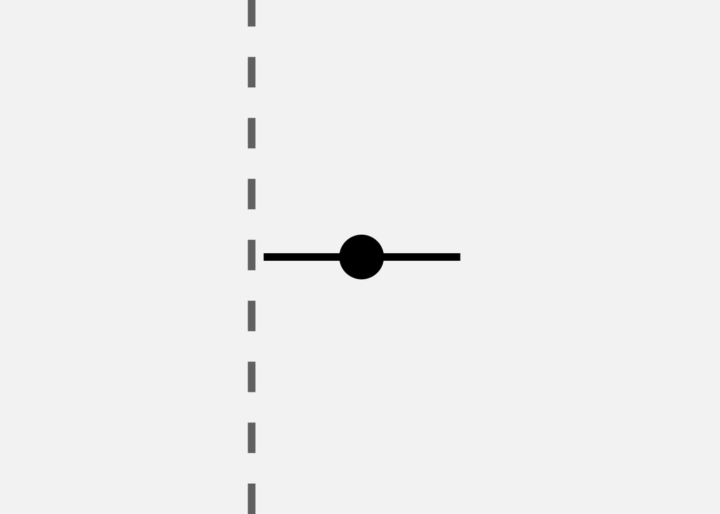

```r
or_limits <- c(0.2, 20)

forest_cell <- function(or, low, high) {
  if (is.na(or)) {
    plot_data <- tibble(or = NA_real_, low = NA_real_, high = NA_real_)
  } else {
    plot_data <- tibble(or = or,
                        low = pmax(low, or_limits[1]),
                        high = pmin(high, or_limits[2]))
  }

  ggplot(plot_data, aes(x = or, y = 1)) +
    annotate("rect", xmin = or_limits[1], xmax = or_limits[2],
             ymin = 0.5, ymax = 1.5, fill = "grey96") +
    geom_vline(xintercept = 1, linetype = "dashed",
               colour = "grey45", linewidth = 2.5) +
    geom_segment(aes(x = low, xend = high, y = 1, yend = 1),
                 linewidth = 2.5, na.rm = TRUE) +
    geom_point(size = 14, na.rm = TRUE) +
    scale_x_continuous(transform = "log", limits = or_limits, expand = c(0, 0)) +
    scale_y_continuous(limits = c(0.5, 1.5), expand = c(0, 0)) +
    theme_void()
}

forest_cell(2.02, 1.08, 3.80)
```

`gt::ggplot_image()` turns a plot object into an inline image that a table cell can hold. We build one image per row.

```r
results_formatted <- results_formatted %>%
  mutate(
    uni_plot = pmap_chr(list(uni_or, uni_low, uni_high), function(o, l, h) {
      ggplot_image(forest_cell(o, l, h), height = 26, aspect_ratio = 4.5)
    }),
    multi_plot = pmap_chr(list(multi_or, multi_low, multi_high), function(o, l, h) {
      ggplot_image(forest_cell(o, l, h), height = 26, aspect_ratio = 4.5)
    })
  )
```

# PART 6: Draw the table

Everything is now a string, so the `gt` call only has to arrange and label.

```r
final_table <- results_formatted %>%
  dplyr::select(variable, row_label, n_total, n_events_display, percent_html,
                uni_text, uni_plot, multi_text, multi_plot, p_text) %>%
  gt(groupname_col = "variable") %>%
  fmt_markdown(columns = c(percent_html, uni_plot, multi_plot)) %>%
  cols_label(
    row_label = "",
    n_total = "Num births",
    n_events_display = "Num low birth weight",
    percent_html = "% low birth weight",
    uni_text = "Univariable OR (95% CI)",
    uni_plot = "",
    multi_text = "Multivariable OR (95% CI)",
    multi_plot = "",
    p_text = "p-value"
  ) %>%
  cols_align(align = "left", columns = c(row_label, percent_html)) %>%
  cols_align(align = "center", columns = c(n_total, n_events_display,
                                           uni_text, multi_text, p_text)) %>%
  tab_style(style = cell_text(weight = "bold"), locations = cells_row_groups()) %>%
  tab_style(
    style = cell_text(style = "italic", color = "#5d7475"),
    locations = cells_body(columns = row_label,
                           rows = results_formatted$row_type == "band")
  ) %>%
  tab_style(
    style = cell_fill(color = "#eef1fb"),
    locations = cells_body(rows = results_formatted$level == "Continuous")
  ) %>%
  tab_header(
    title = md("**Factors associated with low birth weight**"),
    subtitle = "Baystate Medical Center, 1986 (n = 189)"
  ) %>%
  tab_footnote(
    footnote = "Age and weight were modelled as continuous linear terms. Bands are shown for description only and have no odds ratio.",
    locations = cells_column_labels(columns = row_label)
  ) %>%
  tab_options(table.font.size = px(13), data_row.padding = px(4))

final_table
```

**Factors associated with low birth weight**

Baystate Medical Center, 1986 (n = 189)

<sup>1</sup>

Num births

Num low birth weight

% low birth weight

Univariable OR (95% CI)

Multivariable OR (95% CI)

p-value

Age, years

Continuous, per 5 years

189

*mean 23.2 (SD 5.3)*

0.77 (0.56 – 1.05)

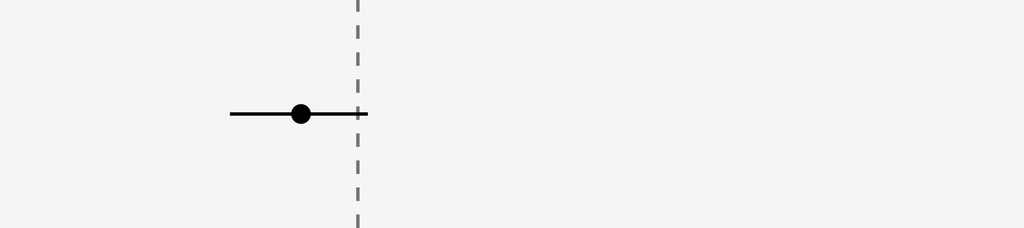

0.79 (0.54 – 1.12)

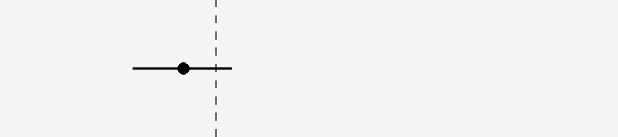

0.197

14-19

51

15

29.4

–

–

20-24

69

25

36.2

–

–

25-29

42

15

35.7

–

–

30+

27

4

14.8

–

–

Weight at last period, lb

Continuous, per 10 lb

189

*mean 129.8 (SD 30.6)*

0.87 (0.76 – 0.97)

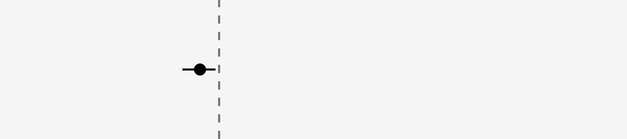

0.89 (0.78 – 1.01)

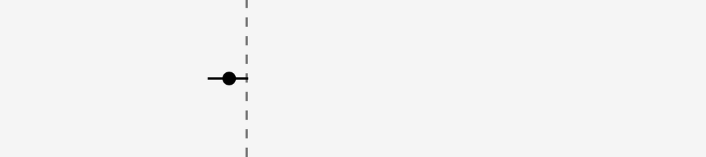

0.088

80-110

53

25

47.2

–

–

111-130

70

20

28.6

–

–

131-150

30

7

23.3

–

–

151+

36

7

19.4

–

–

Race

White

96

23

24.0

1 (reference)

1 (reference)

Black

26

11

42.3

2.33 (0.93 – 5.77)

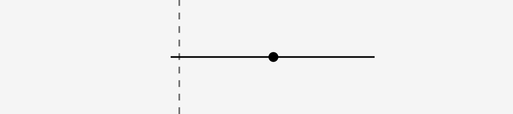

3.01 (1.06 – 8.75)

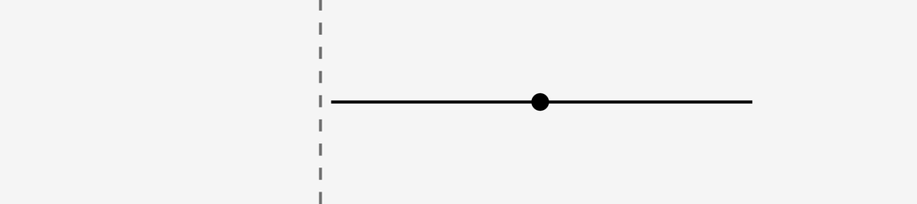

0.039

Other

67

25

37.3

1.89 (0.96 – 3.76)

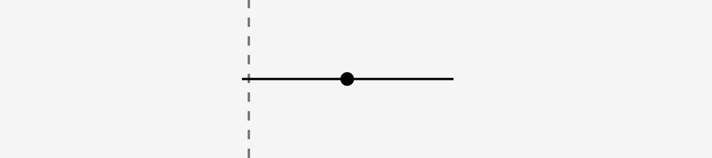

2.25 (0.96 – 5.39)

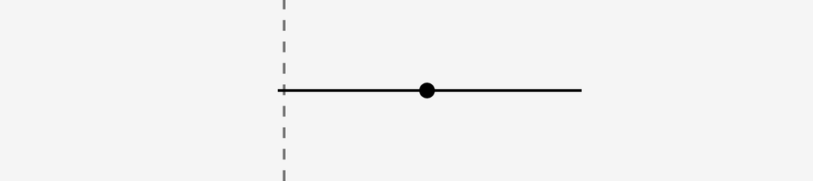

0.064

Smoking during pregnancy

No

115

29

25.2

1 (reference)

1 (reference)

Yes

74

30

40.5

2.02 (1.08 – 3.80)

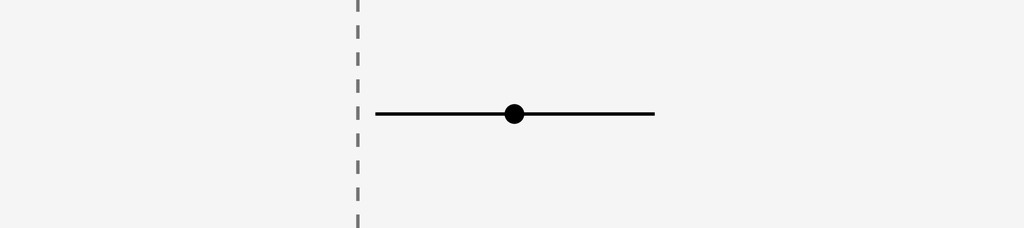

2.39 (1.10 – 5.36)

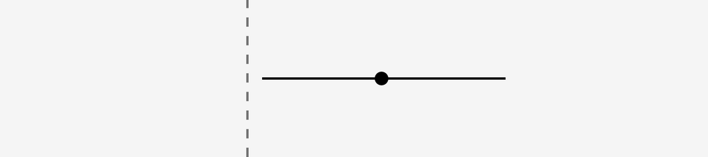

0.030

Previous premature labours

0

159

41

25.8

1 (reference)

1 (reference)

1

24

16

66.7

5.76 (2.35 – 15.14)

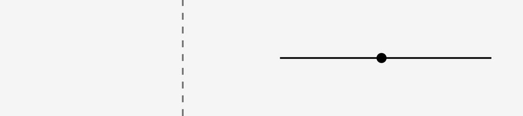

5.30 (2.01 – 15.13)

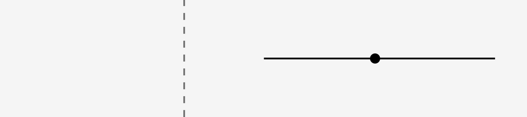

0.001

2+

6

2

33.3

1.44 (0.19 – 7.66)

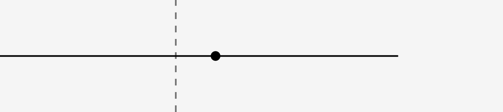

1.09 (0.14 – 6.24)

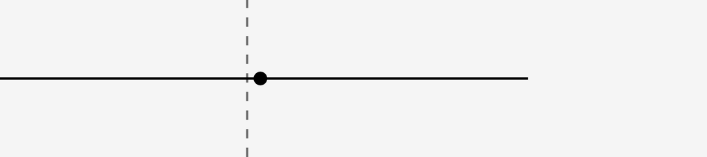

0.925

<sup>1</sup> Age and weight were modelled as continuous linear terms. Bands are shown for description only and have no odds ratio.

# PART 7: What to take from this

- **Raw numbers and model estimates come from different places.** Build them separately, then join on a key. Here the key is `term`, the name R gives each coefficient.
- **A continuous predictor needs two row types.** One row carries the odds ratio per unit step; the descriptive band rows carry percentages and no odds ratio. Say so in a footnote, so nobody reads the bands as separate estimates.
- **Rescale continuous predictors** to a step that a reader can picture. Per 5 years is easier to hold in mind than per year.
- **Reference levels have no coefficient.** After the join they are `NA`, which is your cue to print “1 (reference)”.
- **Fix the forest plot x-axis once** and clip anything that runs off the edge. Per-cell automatic scales silently mislead.
- **Do the formatting in `dplyr`, not in `gt`.** Then you can print the intermediate table and check every value.

Export it when you need to hand it over:

```r
gtsave(final_table, "birthwt_regression_table.html")
```

# Reference

Venables WN, Ripley BD (2002). *Modern Applied Statistics with S*, 4th edition. Springer. The `birthwt` data originally come from Hosmer DW, Lemeshow S (1989), *Applied Logistic Regression*.